# Projekt_CV

## Tematyka zadania

Celem tego projektu jest zbudowanie modelu konwolucyjnej sieci neuronowej służącej do klasyfikacji dzieł sztuki ze względu na gatunek (11 etykiet) oraz stylów malarskich (27 etykiet).

Zbiór danych którym posłużyliśmy się do trenowania modeli jest WikiArt zawierający ponad 84 tysiące różnych obrazów. Zbiór ten funkcjonuje w otwartym dostępie i jest darmowy do niekomercyjnego użytku.

## Klasyfikacja gatunku obrazu

Każdy z obrazów posiada etykietę wskazującą na gatunek obrazu:

- 0 - Malarstwo abstrakcyjne
- 1 - Pejzaż miejski
- 2 - Malarstwo rodzajowe
- 3 - Ilustracja
- 4 - Pejzaż
- 5 - Malarstwo nagie
- 6 - Portret
- 7 - Malarstwo religijne
- 8 - Szkic
- 9 - Martwa natura
- 10 - Gatunek nieznany

### Pierwszy projekt sieci

Pierwsza testowana przez nas architekutra sieci jest stosunkowo prosta ponieważ składa się jedynie z 4 warstw konwolucyjnych i max poolingowych ze stosunkowo niewielką ilością filtrów.

**Kod**

```r
model <- keras_model_sequential() %>%
  layer_conv_2d(filters = 32, kernel_size = c(3, 3), activation = "relu",
                input_shape = c(150, 150, 3)) %>%
  layer_max_pooling_2d(pool_size = c(2, 2)) %>%
  layer_conv_2d(filters = 64, kernel_size = c(3, 3), activation = "relu") %>%
  layer_max_pooling_2d(pool_size = c(2, 2)) %>%
  layer_conv_2d(filters = 128, kernel_size = c(3, 3), activation = "relu") %>%
  layer_max_pooling_2d(pool_size = c(2, 2)) %>%
  layer_conv_2d(filters = 128, kernel_size = c(3, 3), activation = "relu") %>%
  layer_max_pooling_2d(pool_size = c(2, 2)) %>%
  layer_flatten() %>%
  layer_dense(units = 512, activation = "relu") %>%
  layer_dense(units = 11, activation = "softmax")
```

```
Model: "sequential"
________________________________________________________________________________
Layer (type)                        Output Shape                    Param #
================================================================================
conv2d_3 (Conv2D)                   (None, 148, 148, 32)            896
________________________________________________________________________________
max_pooling2d_3 (MaxPooling2D)      (None, 74, 74, 32)              0
________________________________________________________________________________
conv2d_2 (Conv2D)                   (None, 72, 72, 64)              18496
________________________________________________________________________________
max_pooling2d_2 (MaxPooling2D)      (None, 36, 36, 64)              0
________________________________________________________________________________
conv2d_1 (Conv2D)                   (None, 34, 34, 128)             73856
________________________________________________________________________________
max_pooling2d_1 (MaxPooling2D)      (None, 17, 17, 128)             0
________________________________________________________________________________
conv2d (Conv2D)                     (None, 15, 15, 128)             147584
________________________________________________________________________________
max_pooling2d (MaxPooling2D)        (None, 7, 7, 128)               0
________________________________________________________________________________
flatten (Flatten)                   (None, 6272)                    0
________________________________________________________________________________
dense_1 (Dense)                     (None, 512)                     3211776
________________________________________________________________________________
dense (Dense)                       (None, 11)                      5643
================================================================================
Total params: 3,458,251
Trainable params: 3,458,251
Non-trainable params: 0
________________________________________________________________________________
```

Szkolenie w każdej epoce odbywało się na 3200 obrazkach oraz była przeprowadzana walidacja na 1600 obrazkach.

Funkcją optymalizującą był “Adam” oraz zastosowane były następujące callbacki:

- Zapisywanie modelu po każdej epoce
- Przerwanie procesu uczenia jeżeli celność nie poprawi się na zbiorze walidacyjnym po 5 epokach

Przy tej strukturze sieć szkoliła się przez 28 epok kończąc proces uczenia przez zastosowanie callbacków ze względu na brak poprawy celności na zbiorze walidacyjnym.

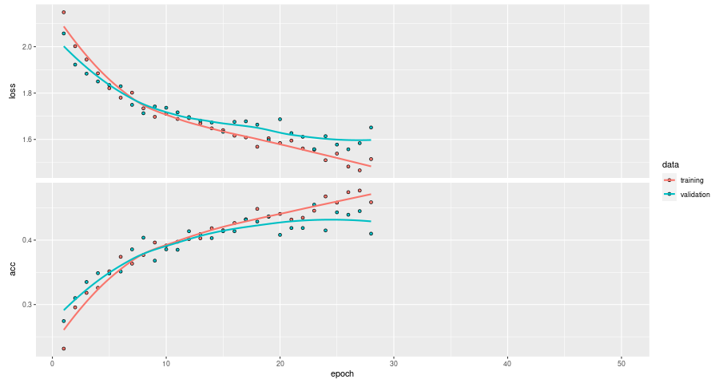

Pierwsza siec

Widać że nastąpiło zjawisko przeuczenia. Najwyższą celnościa na zbiorze walidacyjnym było ~45%.

### Drugi projekt sieci

Druga architektura składa się z większej liczby warstw konwolucyjnych oraz większej ilości filtrów. Dodatkowo tym razem dodaliśmy warstwy dropout’ów w celu redukcji przeuczenia sieci.

**Kod**

```r
model <- keras_model_sequential() %>%
  layer_conv_2d(filters = 128, kernel_size = c(3, 3), activation = "relu",
                input_shape = c(150, 150, 3)) %>%
  layer_conv_2d(filters = 128, kernel_size = c(3, 3), activation = "relu") %>%
  layer_max_pooling_2d(pool_size = c(2, 2)) %>%
  layer_dropout(rate = 0.2) %>%
  layer_conv_2d(filters = 64, kernel_size = c(3, 3), activation = "relu") %>%
  layer_conv_2d(filters = 64, kernel_size = c(3, 3), activation = "relu") %>%
  layer_max_pooling_2d(pool_size = c(2, 2)) %>%
  layer_dropout(rate = 0.3) %>%
  layer_conv_2d(filters = 128, kernel_size = c(3, 3), activation = "relu") %>%
  layer_conv_2d(filters = 32, kernel_size = c(3, 3), activation = "relu") %>%
  layer_max_pooling_2d(pool_size = c(2, 2)) %>%
  layer_dropout(rate = 0.3) %>%
  layer_flatten() %>%
  layer_dense(units = 256, activation = "relu") %>%
  layer_dense(units = 54, activation = "relu") %>%
  layer_dropout(rate = 0.5) %>%
  layer_dense(units = 11, activation = "softmax")
```

```
Model: "sequential_1"
________________________________________________________________________________
Layer (type)                        Output Shape                    Param #
================================================================================
conv2d_9 (Conv2D)                   (None, 148, 148, 128)           3584
________________________________________________________________________________
conv2d_8 (Conv2D)                   (None, 146, 146, 128)           147584
________________________________________________________________________________
max_pooling2d_6 (MaxPooling2D)      (None, 73, 73, 128)             0
________________________________________________________________________________
dropout_3 (Dropout)                 (None, 73, 73, 128)             0
________________________________________________________________________________
conv2d_7 (Conv2D)                   (None, 71, 71, 64)              73792
________________________________________________________________________________
conv2d_6 (Conv2D)                   (None, 69, 69, 64)              36928
________________________________________________________________________________
max_pooling2d_5 (MaxPooling2D)      (None, 34, 34, 64)              0
________________________________________________________________________________
dropout_2 (Dropout)                 (None, 34, 34, 64)              0
________________________________________________________________________________
conv2d_5 (Conv2D)                   (None, 32, 32, 128)             73856
________________________________________________________________________________
conv2d_4 (Conv2D)                   (None, 30, 30, 32)              36896
________________________________________________________________________________
max_pooling2d_4 (MaxPooling2D)      (None, 15, 15, 32)              0
________________________________________________________________________________
dropout_1 (Dropout)                 (None, 15, 15, 32)              0
________________________________________________________________________________
flatten_1 (Flatten)                 (None, 7200)                    0
________________________________________________________________________________
dense_4 (Dense)                     (None, 256)                     1843456
________________________________________________________________________________
dense_3 (Dense)                     (None, 54)                      13878
________________________________________________________________________________
dropout (Dropout)                   (None, 54)                      0
________________________________________________________________________________
dense_2 (Dense)                     (None, 11)                      605
================================================================================
Total params: 2,230,579
Trainable params: 2,230,579
Non-trainable params: 0
________________________________________________________________________________
```

Uczenie tym razem odbywało się na 51 200 obrazach w epoce, a następnie model walidowany był na 12 800 obrazach.

Funkcją optymalizującą również był “Adam” oraz zastosowane były te same callbacki co przy wcześniejszej architekturze.

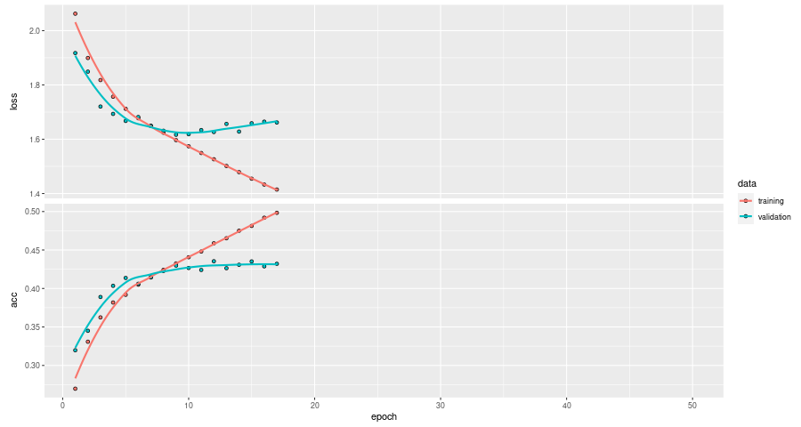

Druga siec

Niestety także i przy tej architekturze nastąpiło zjawisko przeuczenia (nawet szybciej niż w przypadku sieci poprzedniej) osiągając accuracy maksymalnie na poziomie 0.45.

### Trzeci projekt sieci

Tym razem zdecydowaliśmy się użyć wcześniej przeszkolonej sieci ResNet jako części konwolucyjnej. Ze względu na ograniczone zasoby obliczeniowe użyliśmy wersji ResNet50.

```r
conv_base <- application_resnet50(
  weights = "imagenet",
  include_top = F,
  input_shape = c(224,224,3)
)
```

```r
freeze_weights(conv_base)
unfreeze_weights(conv_base, from = "conv5_block3_2_conv")
```

Odmrażamy dwa ostatnie bloki konwolucyjne i normalizujące partię w celu dostrojenia sieci do naszego zadania.

**Kod**

```r
model <- keras_model_sequential() %>%
  conv_base %>%
  layer_flatten() %>%
  layer_dense(units = 512, activation = "relu") %>%
  layer_dense(units = 11, activation = "softmax")
```

```
Model: "sequential_2"
_____________________________________________________________________
Layer (type)                   Output Shape               Param #
=====================================================================
resnet50 (Functional)          (None, 7, 7, 2048)         23587712
_____________________________________________________________________
flatten_2 (Flatten)            (None, 100352)             0
_____________________________________________________________________
dense_6 (Dense)                (None, 512)                51380736
_____________________________________________________________________
dense_5 (Dense)                (None, 11)                 5643
=====================================================================
Total params: 74,974,091
Trainable params: 54,801,931
Non-trainable params: 20,172,160
_____________________________________________________________________
```

Sieć uczona była na pełnym zbiorze treningowym przy użyciu optimizera “Adam” i tych samch callbacków co przy poprzednich architekturach.

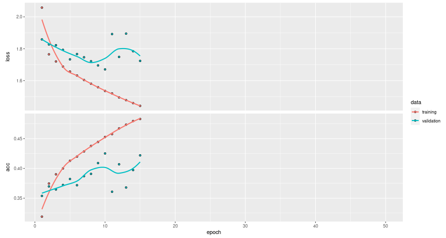

Trzecia siec

W tym przypadku zjawisko przeuczenia nastąpiło nawet szybiciej niż przy poprzednich architekturach.

### Czwarty projekt sieci

**Kod**

```r
model <- keras_model_sequential() %>%
  layer_conv_2d(filters = 128, kernel_size = c(3, 3),
                input_shape = c(224, 224, 3)) %>%
  layer_activation_leaky_relu(alpha = 0.1) %>%
  layer_max_pooling_2d(pool_size = c(2, 2)) %>%
  layer_conv_2d(filters = 128, kernel_size = c(3, 3)) %>%
  layer_activation_leaky_relu(alpha = 0.1) %>%
  layer_max_pooling_2d(pool_size = c(2, 2)) %>%
  layer_dropout(rate = 0.2) %>%
  layer_conv_2d(filters = 64, kernel_size = c(3, 3)) %>%
  layer_activation_leaky_relu(alpha = 0.1) %>%
  layer_max_pooling_2d(pool_size = c(2, 2)) %>%
  layer_dropout(rate = 0.3) %>%
  layer_conv_2d(filters = 32, kernel_size = c(3, 3)) %>%
  layer_activation_leaky_relu(alpha = 0.1) %>%
  layer_max_pooling_2d(pool_size = c(2, 2)) %>%
  layer_flatten() %>%
  layer_dropout(rate = 0.5) %>%
  layer_dense(units = 512, activation = "relu") %>%
  layer_activity_regularization(l2 = 0.001) %>%
  layer_dense(units = 11, activation = "softmax")
```

```
Model: "sequential_3"
________________________________________________________________________________
Layer (type)                        Output Shape                    Param #
================================================================================
conv2d_13 (Conv2D)                  (None, 222, 222, 128)           3584
________________________________________________________________________________
leaky_re_lu_3 (LeakyReLU)           (None, 222, 222, 128)           0
________________________________________________________________________________
max_pooling2d_10 (MaxPooling2D)     (None, 111, 111, 128)           0
________________________________________________________________________________
conv2d_12 (Conv2D)                  (None, 109, 109, 128)           147584
________________________________________________________________________________
leaky_re_lu_2 (LeakyReLU)           (None, 109, 109, 128)           0
________________________________________________________________________________
max_pooling2d_9 (MaxPooling2D)      (None, 54, 54, 128)             0
________________________________________________________________________________
dropout_6 (Dropout)                 (None, 54, 54, 128)             0
________________________________________________________________________________
conv2d_11 (Conv2D)                  (None, 52, 52, 64)              73792
________________________________________________________________________________
leaky_re_lu_1 (LeakyReLU)           (None, 52, 52, 64)              0
________________________________________________________________________________
max_pooling2d_8 (MaxPooling2D)      (None, 26, 26, 64)              0
________________________________________________________________________________
dropout_5 (Dropout)                 (None, 26, 26, 64)              0
________________________________________________________________________________
conv2d_10 (Conv2D)                  (None, 24, 24, 32)              18464
________________________________________________________________________________
leaky_re_lu (LeakyReLU)             (None, 24, 24, 32)              0
________________________________________________________________________________
max_pooling2d_7 (MaxPooling2D)      (None, 12, 12, 32)              0
________________________________________________________________________________
flatten_3 (Flatten)                 (None, 4608)                    0
________________________________________________________________________________
dropout_4 (Dropout)                 (None, 4608)                    0
________________________________________________________________________________
dense_8 (Dense)                     (None, 512)                     2359808
________________________________________________________________________________
activity_regularization (ActivityRe (None, 512)                     0
________________________________________________________________________________
dense_7 (Dense)                     (None, 11)                      5643
================================================================================
Total params: 2,608,875
Trainable params: 2,608,875
Non-trainable params: 0
________________________________________________________________________________
```

Ze względu na fakt że pierwsza architektura pomimo najprostrzej struktury dawała relatywnie najlepsze wyniki zdecydowaliśmy się do niej wrócić z modyfikacjami w postaci regurlaryzacji oraz funkcji aktywacji w postaci “leaky reLU”.

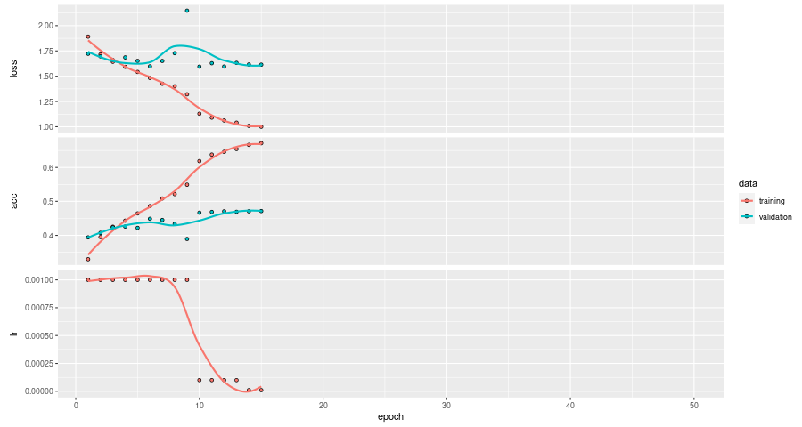

Czwarta siec

Podczas uczenia callbacki ustawione były na:

- Zapisywanie modelu po każdej epoce
- Przerwanie procesu uczenia jeżeli funkcja straty nie poprawi się na zbiorze walidacyjnym po 5 epokach
- Obniżenie learning rate jeżeli funkcja straty nie poprawi się na zbiorze walidacyjnym po 3 epokach

W porównaniu do wszystkich poprzednich struktur ta wypada najlepiej zarówno na zbiorze uczącym (~67% celności) jak i walidacyjnym (~47% celności).

Niestety pomimo lepszych wyników uczenia oraz obniżenia learning rate (widać że za pierwszym razem poprawił celność) model jest przeuczony.

### Piąty projekt sieci

Zachęceni wynikami uzyskanymi na stylach z szkolonej od początku architektury DensNet121 postawnowiliśmy użyć jej również do klasyfikacji garunków.

```r
conv_base <- application_densenet121(
  weights = NULL,
  include_top = TRUE,
  classes = 11,
  input_shape = c(224, 224, 3)
)

model <- conv_base
```

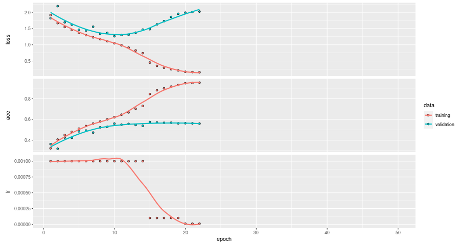

Piata siec

Także i w tym przypadku architektura ta okazała się najlepsza z dotychczasowych osiągając blisko 60% na zbiorze walidacyjnym.

## Klasyfikacja stylu obrazu

- 0 - Abstrakcjonizm ekspresyjny
- 1 - Malowidło akcji
- 2 - Kubizm anlityczny
- 3 - Secesja
- 4 - Barok
- 5 - Malarstwo barwnych płaszczyzn
- 6 - Realizm współczesny
- 7 - Kubizm
- 8 - Wczesny Renesans
- 9 - Ekspresjonizm
- 10 - Fowizm
- 11 - Późny renesans
- 12 - Impresjonizm
- 13 - Manieryzm późnego renesansu
- 14 - Minimalizm
- 15 - Prymitywizm (Naïve art)
- 16 - Nowy realizm
- 17 - Renesans północny
- 18 - Puentylizm
- 19 - Pop-art
- 20 - Postimpresjonizm
- 21 - Realizm
- 22 - Rokoko
- 23 - Romantyzm
- 24 - Symbolizm
- 25 - Kubizm syntetyczny
- 26 - Ukiyo-e
- 27 - Styl nieznany

### Pierwszy projekt sieci

Pierwszą architekturę sieci do rozpoznawania styli malarstwa postanowiliśmy oprzeć o wcześniej wyuczoną sieć ResNet50 z odmrożonymi dwoma blokami konwolucji.

W tym przypadku zdecydowaliśmy się na mniejszy blok gęsty względem architektury do rozpoznawania gatunków.

**Kod**

```r
model <- keras_model_sequential() %>%
  conv_base %>%
  layer_flatten() %>%
  layer_dense(units = 256, activation = "relu") %>%
  layer_dense(units = 27, activation = "softmax")
```

[output not shown]

Podczas uczenia callbacki ustawione były na:

- Zapisywanie modelu po każdej epoce
- Przerwanie procesu uczenia jeżeli funkcja straty nie poprawi się na zbiorze walidacyjnym po 8 epokach
- Obniżenie learning rate jeżeli funkcja straty nie poprawi się na zbiorze walidacyjnym po 4 epokach

Niestety proces uczenia został przerwany ze względu na limity platformy kaggle (kompilacja notatnika osiągnęła 12h) z tego względu dysponujemy jedynie logami dla rezultatów 27 epoki

loss: 2.1323 - acc: 0.3101 - val_loss: 2.2895 - val_acc: 0.2795 - lr: 1.0000e-06

### Drugi projekt sieci

Jako drugą architekturę sieci postanowiliśmy wykorzystać czwartą architekturę zaproponowaną do klasyfikacji gatunków ze względu na fakt że osiągała ona najlepsze wyniki.

**Kod**

```r
model <- keras_model_sequential() %>%
  layer_conv_2d(filters = 128, kernel_size = c(3, 3),
                input_shape = c(224, 224, 3)) %>%
  layer_activation_leaky_relu(alpha = 0.1) %>%
  layer_max_pooling_2d(pool_size = c(2, 2)) %>%
  layer_conv_2d(filters = 128, kernel_size = c(3, 3)) %>%
  layer_activation_leaky_relu(alpha = 0.1) %>%
  layer_max_pooling_2d(pool_size = c(2, 2)) %>%
  layer_dropout(rate = 0.2) %>%
  layer_conv_2d(filters = 64, kernel_size = c(3, 3)) %>%
  layer_activation_leaky_relu(alpha = 0.1) %>%
  layer_max_pooling_2d(pool_size = c(2, 2)) %>%
  layer_dropout(rate = 0.3) %>%
  layer_conv_2d(filters = 32, kernel_size = c(3, 3)) %>%
  layer_activation_leaky_relu(alpha = 0.1) %>%
  layer_max_pooling_2d(pool_size = c(2, 2)) %>%
  layer_flatten() %>%
  layer_dropout(rate = 0.5) %>%
  layer_dense(units = 512, activation = "relu") %>%
  layer_activity_regularization(l2 = 0.001) %>%
  layer_dense(units = 27, activation = "softmax")
```

```
Model: "sequential_5"
________________________________________________________________________________
Layer (type)                        Output Shape                    Param #
================================================================================
conv2d_17 (Conv2D)                  (None, 222, 222, 128)           3584
________________________________________________________________________________
leaky_re_lu_7 (LeakyReLU)           (None, 222, 222, 128)           0
________________________________________________________________________________
max_pooling2d_14 (MaxPooling2D)     (None, 111, 111, 128)           0
________________________________________________________________________________
conv2d_16 (Conv2D)                  (None, 109, 109, 128)           147584
________________________________________________________________________________
leaky_re_lu_6 (LeakyReLU)           (None, 109, 109, 128)           0
________________________________________________________________________________
max_pooling2d_13 (MaxPooling2D)     (None, 54, 54, 128)             0
________________________________________________________________________________
dropout_9 (Dropout)                 (None, 54, 54, 128)             0
________________________________________________________________________________
conv2d_15 (Conv2D)                  (None, 52, 52, 64)              73792
________________________________________________________________________________
leaky_re_lu_5 (LeakyReLU)           (None, 52, 52, 64)              0
________________________________________________________________________________
max_pooling2d_12 (MaxPooling2D)     (None, 26, 26, 64)              0
________________________________________________________________________________
dropout_8 (Dropout)                 (None, 26, 26, 64)              0
________________________________________________________________________________
conv2d_14 (Conv2D)                  (None, 24, 24, 32)              18464
________________________________________________________________________________
leaky_re_lu_4 (LeakyReLU)           (None, 24, 24, 32)              0
________________________________________________________________________________
max_pooling2d_11 (MaxPooling2D)     (None, 12, 12, 32)              0
________________________________________________________________________________
flatten_5 (Flatten)                 (None, 4608)                    0
________________________________________________________________________________
dropout_7 (Dropout)                 (None, 4608)                    0
________________________________________________________________________________
dense_12 (Dense)                    (None, 512)                     2359808
________________________________________________________________________________
activity_regularization_1 (Activity (None, 512)                     0
________________________________________________________________________________
dense_11 (Dense)                    (None, 27)                      13851
================================================================================
Total params: 2,617,083
Trainable params: 2,617,083
Non-trainable params: 0
________________________________________________________________________________
```

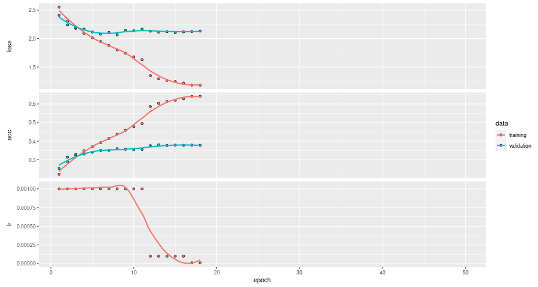

Druga siec

Pomimo faktu, że i przy tej strukturze sieci następuje przeuczenie osiąga ona taki sam wynik na zbiorze uczącym po 3 epokach co struktura oparta na ResNet50 osiągnęła po 27.

### Trzeci projekt sieci

Pomimo faktu że modele które wykorzystywały wcześniej przetrenowaną sieć konwolucyjną ResNet50 okazały się być gorsze nawet od prostych struktur zdecydowaliśmy się użyć nowszej struktury DensNet121 wykorzystującej bardziej zaawansowane połączenia resztowe.

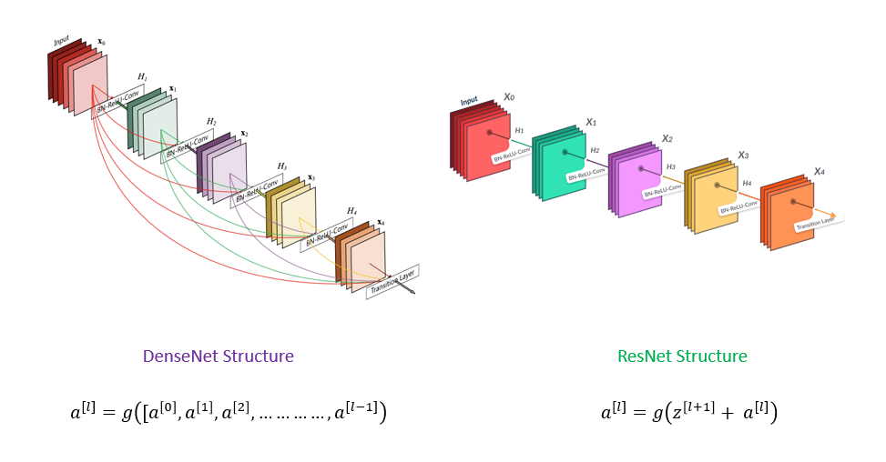

ResNet vs DensNet

Zdecydowaliśmy się na DensNet121 z tego względu iż jest to najmniejsza struktura z architektur DensNet co jest ważne przy ograniczonych zasobach sprzętowych.

Tym razem uznaliśmy jednak, że abstrakcyjny charakter zadania wymaga przeszkolenia całej struktury na nowo, ponieważ wzorce wyuczone na zbiorze “Imagenet” mogą nie dawać zadowalających wyników.

```r
conv_base <- application_densenet121(
  weights = NULL,
  include_top = TRUE,
  classes = 11,
  input_shape = c(224, 224, 3)
)

model <- conv_base
```

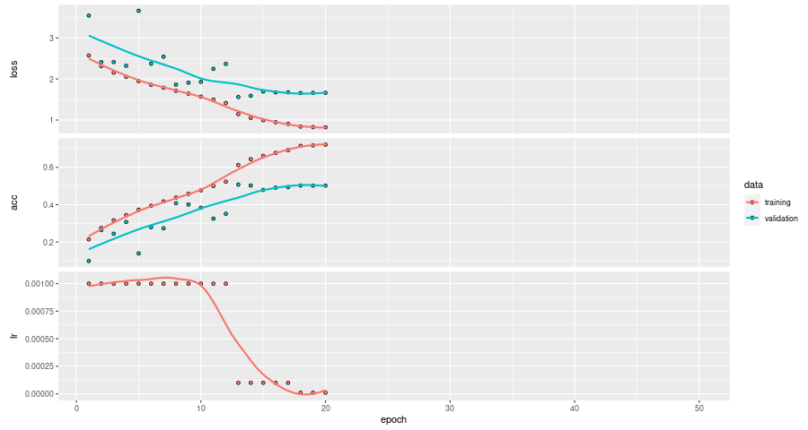

Trzecia siec

Decyzja ta okazała się być trafiona. Po raz pierwszy udało się osiągnąć celnośc powyżej 50% (~52%).